# Reproducible Research: Peer Assessment 1

## Loading and preprocessing the data

First, let’s read the CSV file into memory, assuming the activity.csv file is in your current working directory

```r
actdata <- read.csv("activity.csv", header=T, sep=",")
```

and take a look at it, including performing some basic checks: number of rows, variables and complete rows:

```r
head(actdata)
```

```
##   steps       date interval
## 1    NA 2012-10-01        0
## 2    NA 2012-10-01        5
## 3    NA 2012-10-01       10
## 4    NA 2012-10-01       15
## 5    NA 2012-10-01       20
## 6    NA 2012-10-01       25
```

```r
str(actdata)
```

```
## 'data.frame':    17568 obs. of  3 variables:
##  $ steps   : int  NA NA NA NA NA NA NA NA NA NA ...
##  $ date    : Factor w/ 61 levels "2012-10-01","2012-10-02",..: 1 1 1 1 1 1 1 1 1 1 ...
##  $ interval: int  0 5 10 15 20 25 30 35 40 45 ...
```

```r
nrows <- nrow(actdata)
ncols <- ncol(actdata)
```

The number of rows in the activity data set is 17568 over 3 variables.

We convert the date from level to character.

```r
actdata$date <- as.character(actdata$date)
```

Usually, the check and management of missing values would happen at the start of the file. However, since it is an explicit task in the assignment description at a later stage, this preparatory step is postponed (see below).

## What is mean total number of steps taken per day?

First, aggregate the steps taken by day and calculate its mean and median

```r
actdata.stepsDay <- aggregate(actdata$steps, by=list(actdata$date), FUN=sum, na.rm=F)
actdata.stepsDayMean <- mean(actdata.stepsDay$x, na.rm=T)
actdata.stepsDayMedian <- median(actdata.stepsDay$x, na.rm=T)
```

The mean of number of steps taken per day is 10766. The median of the total number of steps taken per day is 10765.

A histogram of the total number of steps taken each day is shown below:

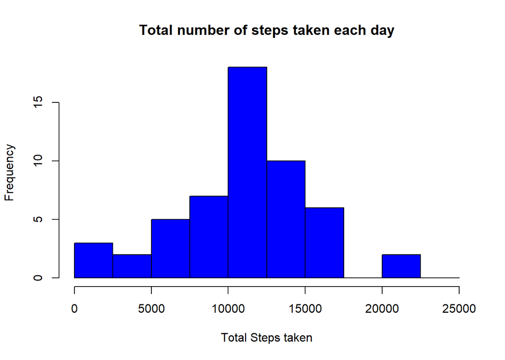

```r
hist(actdata.stepsDay$x,
     breaks=seq(from=0, to=25000, by=2500),
     main="Total number of steps taken each day",
     col="blue",
     xlab="Total Steps taken")
```

## What is the average daily activity pattern?

1. Make a time series plot (i.e. type = “l”) of the 5-minute interval (x-axis) and the average number of steps taken, averaged across all days (y-axis). In other words: what is the average number of steps taken for each intervall across all days (note that intervall IDs repeat every 24h).

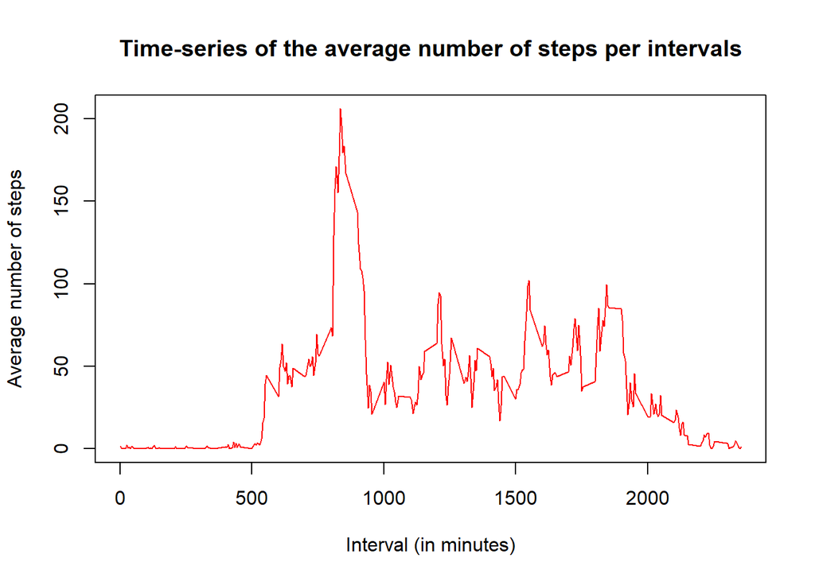

```r
actdata.stepsInterval <- aggregate(actdata$steps, by=list(actdata$interval), FUN=mean, na.rm=T)
plot( x=actdata.stepsInterval[,1],
      y=actdata.stepsInterval[,2],
      type="l",
      col="red",
      main="Time-series of the average number of steps per intervals",
      ylab="Average number of steps",
      xlab="Interval (in minutes)")
```

2. Which 5-minute interval, on average across all the days in the dataset, contains the maximum number of steps?

```r
maxinterval <- actdata.stepsInterval[which.max(actdata.stepsInterval[,2]),1]
```

The 5 -minute interval with the maxium number of steps across all days is 835.

## Imputing missing values

1. Calculate and report the total number of missing values in the dataset (i.e. the total number of rows with NA’s)

```r
nas   <- sum(is.na(actdata))
compl <- sum(complete.cases(actdata))
```

The number of NA’s is 2304.

2. Devise a strategy for filling in all of the missing values in the dataset. The strategy does not need to be sophisticated. For example, you could use the mean/median for that day, or the mean for that 5-minute interval, etc

Strategy: For filling in the missing values, we match Intervall IDs and use the mean steps across all days for a given interval to populate the NAs in the newly created clean dataframe:

```r
actdata.clean <- cbind(actdata, actdata.stepsInterval[,2])
names(actdata.clean)[4] <- c("mean")
actdata.clean$steps <- ifelse( is.na(actdata.clean$steps), actdata.clean$mean, actdata.clean$steps)
```

On the new dataset, calculate again mean and median of total number of steps taken each day:

```r
actdata.clean.stepsDay <- aggregate(actdata.clean$steps, by=list(actdata.clean$date), FUN=sum)
actdata.clean.stepsDayMean <- mean(actdata.clean.stepsDay$x)
actdata.clean.stepsDayMedian <- median(actdata.clean.stepsDay$x,)
```

Now we can also draw the total step count for each day as historgram:

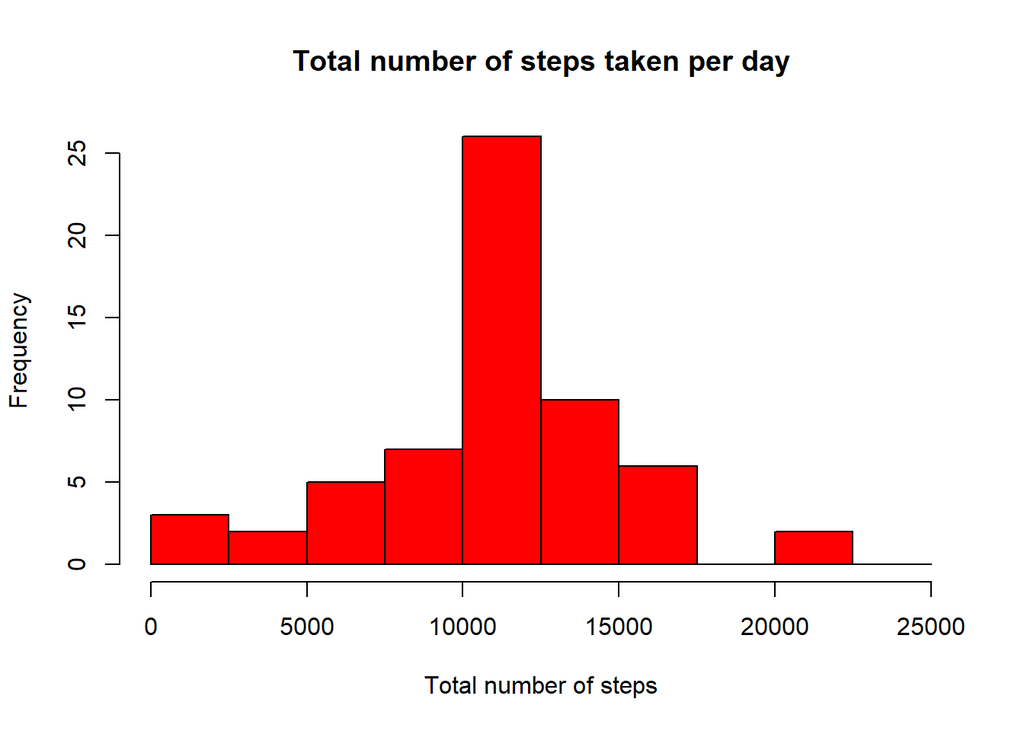

```r
hist(actdata.clean.stepsDay$x,
      breaks=seq(from=0, to=25000, by=2500),
     main="Total number of steps taken per day",
     col="red",
     xlab="Total number of steps")
```

## Are there differences in activity patterns between weekdays and weekends?

```r
actdata.clean$date <- strptime(actdata.clean$date, "%Y-%m-%d")
actdata.clean$weekend <- (weekdays(actdata.clean$date) %in% c("Sunday", "Saturday"))
actdata.weekend <- actdata.clean[actdata.clean$weekend == TRUE,]
actdata.weekday <- actdata.clean[actdata.clean$weekend == FALSE,]
```

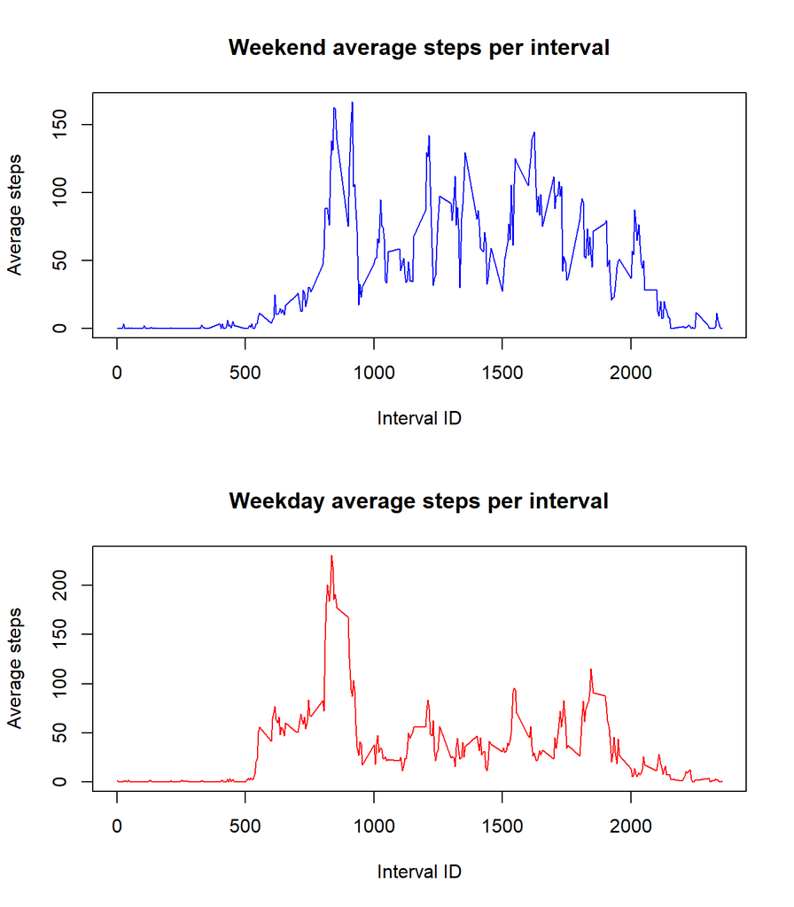

```r
actdata.weekend.steps <- aggregate(actdata.weekend$steps, by=list(actdata.weekend$interval), FUN=mean)
actdata.weekday.steps <- aggregate(actdata.weekday$steps, by=list(actdata.weekday$interval), FUN=mean)
par(mfrow=c(2,1))
plot( x=actdata.weekend.steps[,1],
      y=actdata.weekend.steps[,2],
      type="l",
      col=124,
      main="Weekend average steps per interval",
      ylab="Average steps",
      xlab="Interval ID")
plot( x=actdata.weekday.steps[,1],
      y=actdata.weekday.steps[,2],
      type="l",
      col=554,
      main="Weekday average steps per interval",
      ylab="Average steps",
      xlab="Interval ID")
```